# R - Taller DESUC

22/01/2019

## Motivación

¿Por qué?

- Visualización de datos pueden contar una historia
- Minimizar errores

## Definiciones

- [tidyverse](https://www.tidyverse.org)

*The tidyverse is an opinionated collection of R packages designed for data science. All packages share an underlying design philosophy, grammar, and data structures.*

```r
include_graphics('images/data-science-explore.png')
```

[figure not shown]

## Objetivo

Utilizar R y tidyverse para el manejo de base de datos:

- Presentar gramática de gráficos
- Realizar ejemplos

## Paquetes

```r
library(readxl) # Lectura de archivos excel
library(haven) # Lectura de SPSS o Stata
library(tidyverse) # Básico: dplyr, tidyr, purrr, stringr, forcats
library(janitor) # Arreglo de nombres y tablas

library(sjlabelled) # Manejo de etiquetas
library(sjmisc) # Funciones de ayuda

library(knitr) # Creación de documentos mediante Rmarkdown
```

## Lectura de datos: Bases en texto

Matrícula de alumnos 2018.

```r
df_mat_18 <- read_csv2('../data/20181005_Matrícula_unica_2018_20180430_PUBL.gs.csv.zip')
```

## Grámatica de gráficos

- `data`: base de datos a graficar
- `geom_*`: como se mostraran las variables de la base de datos
- `mappings`: relación entre las variables de la base de datos y elementos del *geom*

```r
ggplot(data = <DATA>) +
  <GEOM_FUNCTION>(mapping = aes(<MAPPINGS>))
```

Los gráficos se construyen capa a capa y ellas se *unen* con el signo `+`. No con `%>%` (la pipa)!

## Gráficos: tip

Hay muy buenos *cheetsheets* donde se pueden revisar diversas funciones existentes.

```r
knitr::include_graphics('ggplot.pdf')
```

[figure not shown]

## Gráfico: iris

- base de datos de iris
- relaciono el elemento *x* del gráfico con `Sepal.Length` y el *y* con `Petal.Length`.

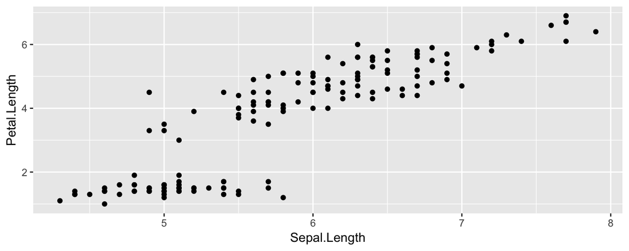

```r
ggplot(iris, aes(x = Sepal.Length, y = Petal.Length)) +
  geom_point()
```

## Gráfico: mapeo de variables

La geometría `geom_point` tiene los siguientes parámetros que pueden ser modificados y *mapeados* a una variable:

- x
- y
- alpha
- colour
- fill
- group
- shape
- size
- stroke

Ver [documentación de la función](https://ggplot2.tidyverse.org/reference/geom_point.html)

## Gráfico: aesthetic

Modifiquemos algunos de esos parámetros.

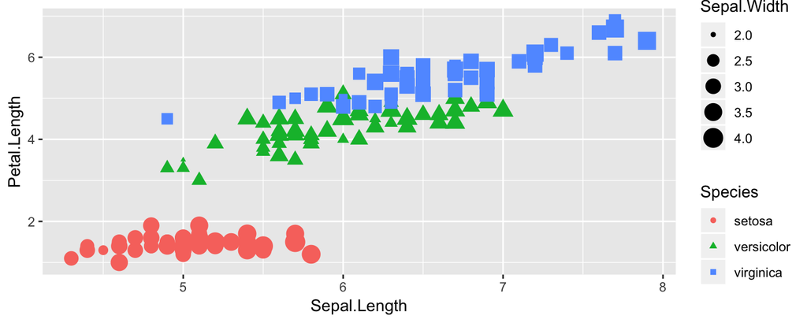

```r
ggplot(iris, aes(x = Sepal.Length, y = Petal.Length,
                 size = Sepal.Width,
                 shape = Species, colour = Species)) +
  geom_point()
```

## Gráfico: aesthetic

¿Cuál es la diferencia de fijar las *aesthetic* en el cuerpo del gráfico o dentro de la geometría?

- Si se fija dentro de `ggplot` afecta a todas las geometrías sucesivas de ese gráfico.
- Si se fija dentro de `geom_*` afecta sólo a esa geometría.

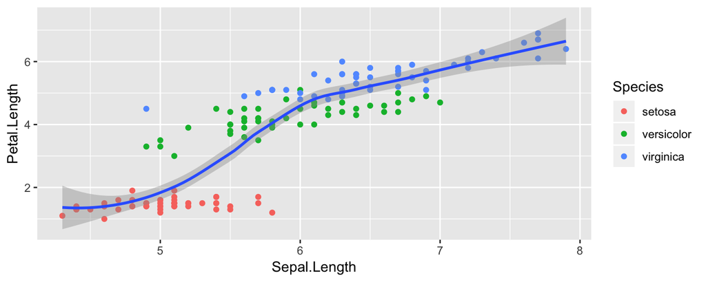

```r
ggplot(iris, aes(x = Sepal.Length, y = Petal.Length)) +
  geom_point(aes(colour = Species)) +
  geom_smooth()
```

## Gráfico: aesthetic

¿Cuál es la diferencia de fijar las *aesthetic* en el cuerpo del gráfico o dentro de la geometría?

- Si se fija dentro de `ggplot` afecta a todas las geometrías sucesivas de ese gráfico.
- Si se fija dentro de `geom_*` afecta sólo a esa geometría.

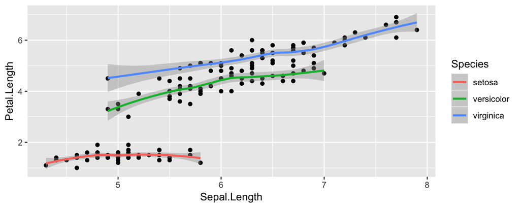

```r
ggplot(iris, aes(x = Sepal.Length, y = Petal.Length)) +
  geom_point() +
  geom_smooth(aes(colour = Species))
```

## Gráfico: Marcadores

Agregar datos específicos para marcar o destacar elementos.

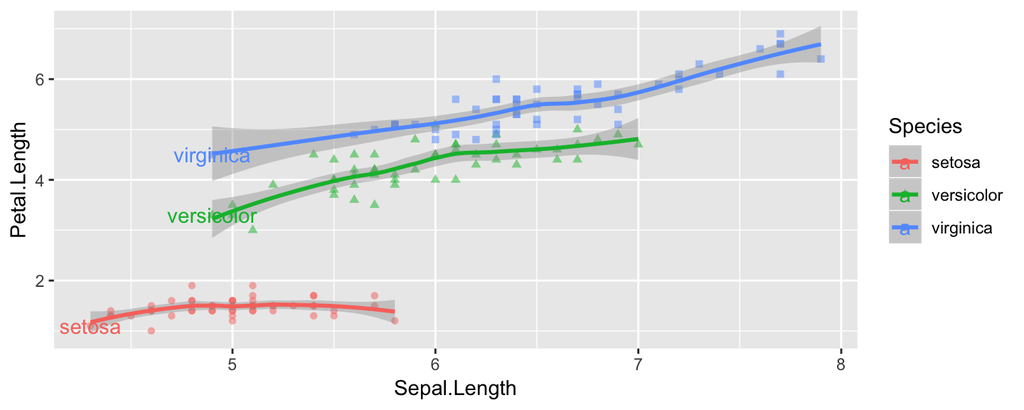

```r
ggplot(iris, aes(x = Sepal.Length, y = Petal.Length, label = Species,
                 shape = Species, colour = Species)) +
  geom_point(alpha = .5) +
  geom_smooth() +
  geom_text(data = iris %>% group_by(Species) %>% top_n(-1, Sepal.Length))
```

## Gráfico: Marcadores

Agregar datos específicos para marcar o destacar elementos.

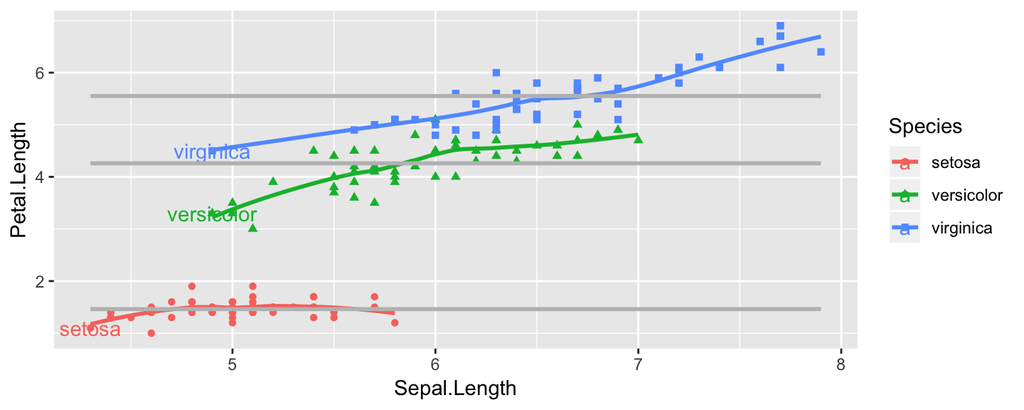

```r
ggplot(iris, aes(x = Sepal.Length, y = Petal.Length, label = Species,
                 shape = Species, colour = Species)) +
  geom_point() +
  geom_smooth(se = FALSE) +
  geom_text(data = iris %>% group_by(Species) %>% top_n(-1, Sepal.Length)) +
  geom_smooth(method = 'lm', formula = y ~ 1, colour = 'gray',
              se = FALSE, fullrange = TRUE)
```

## Gráfico: Marcadores

¿Cómo agrego el promedio de `Petal.Length` de cada grupo?

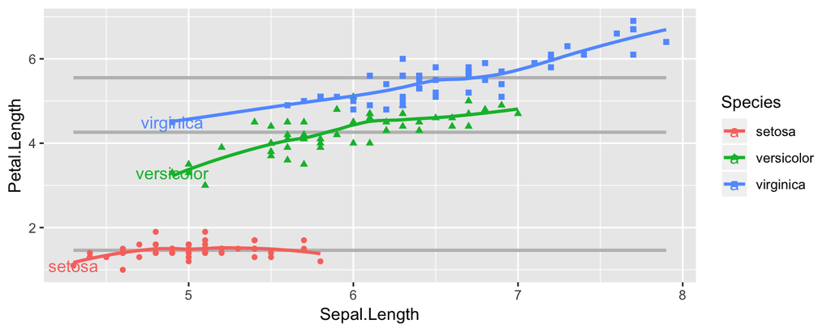

```r
ggplot(iris, aes(x = Sepal.Length, y = Petal.Length, label = Species,
                 shape = Species, colour = Species)) +
  geom_smooth(method = 'lm', formula = y ~ 1, colour = 'gray',
              se = FALSE, fullrange = TRUE) +
  geom_point() +
  geom_text(data = iris %>% group_by(Species) %>% top_n(-1, Sepal.Length)) +
  geom_smooth(se = FALSE)
```

## Gráfico: facets

Otra forma de mostrar diferencias por variable son *facetas*.

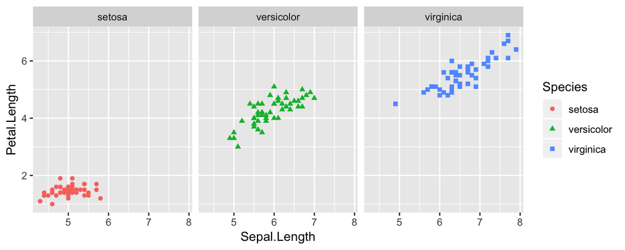

```r
ggplot(iris, aes(x = Sepal.Length, y = Petal.Length,
                 shape = Species, colour = Species)) +
  geom_point() +
  facet_grid(cols = vars(Species))
```

## Gráfico: facets

Otra forma de mostrar diferencias por variable son *facetas*. Se puede convinar una o más variables.

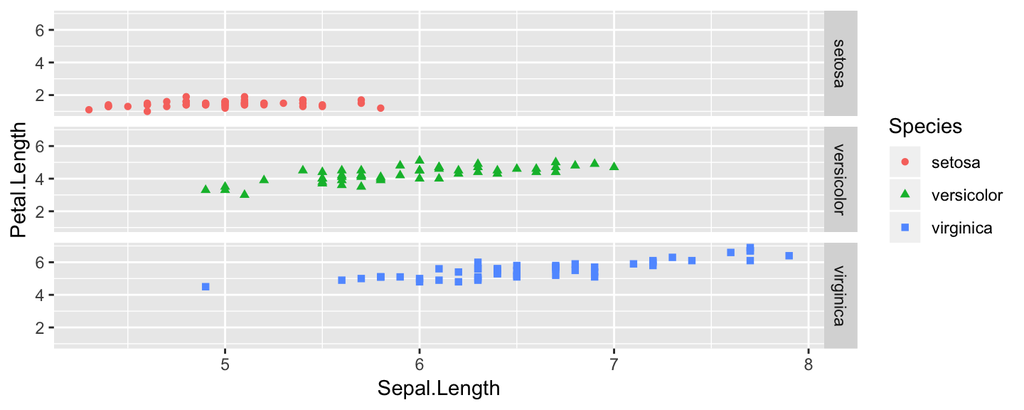

```r
ggplot(iris, aes(x = Sepal.Length, y = Petal.Length,
                 shape = Species, colour = Species)) +
  geom_point() +
  facet_grid(rows = vars(Species))
```

## Gráfico: barras

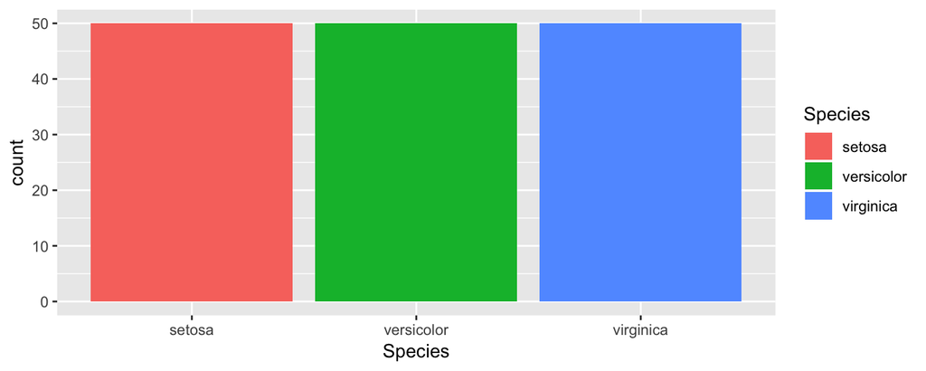

```r
ggplot(iris, aes(x = Species,
                      shape = Species, fill = Species)) +
  geom_bar()
```

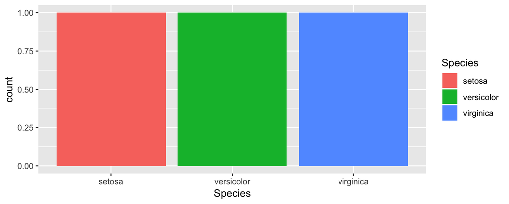

```r
iris_mean <- iris %>%
  group_by(Species) %>%
  summarise(Petal.Length_mean = mean(Petal.Length))

ggplot(iris_mean, aes(x = Species,
                      shape = Species, fill = Species)) +
  geom_bar()
```

## Gráfico: barras

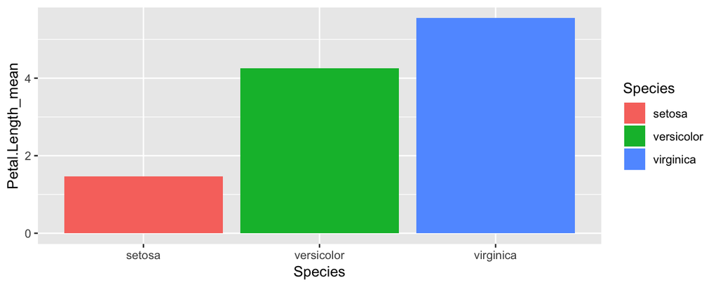

```r
ggplot(iris_mean, aes(x = Species, y = Petal.Length_mean,
                      shape = Species, fill = Species)) +
  geom_col()
```

## Gráfico: barras

Agregar valor a cada barra

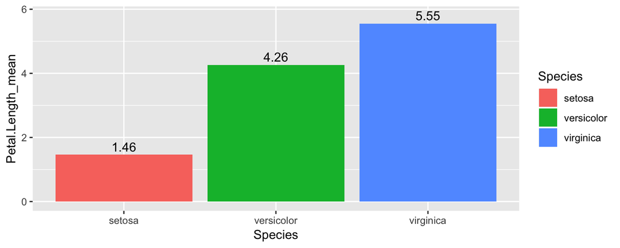

```r
ggplot(iris_mean, aes(x = Species, y = Petal.Length_mean,
                      shape = Species, fill = Species)) +
  geom_col() +
  geom_text(aes(label = round(..y.., 2)),  nudge_y = .25)
```

## Gráfico: estilo

¿Cómo ajustar aspectos de diseño del gráfico?

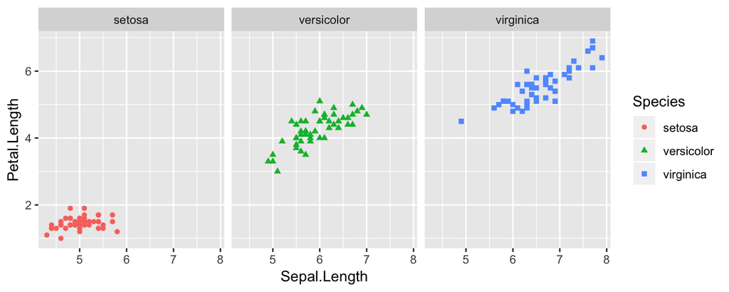

```r
gg <- ggplot(iris, aes(x = Sepal.Length, y = Petal.Length,
                 shape = Species, colour = Species)) +
  geom_point() +
  facet_grid(cols = vars(Species))

gg
```

## Gráfico: estilo

¿Cómo ajustar los títulos del gráfico?

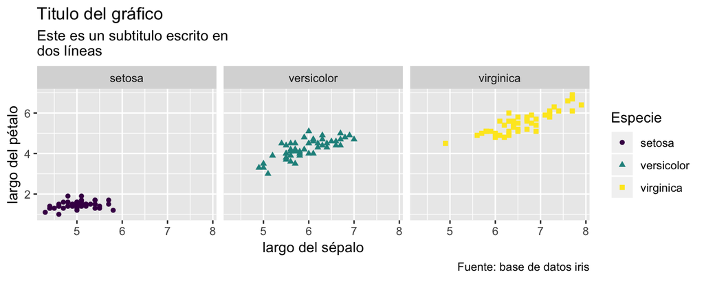

```r
gg +
  labs(title = 'Titulo del gráfico',
       subtitle = 'Este es un subtitulo escrito en\ndos líneas',
       caption = 'Fuente: base de datos iris',
       y = 'largo del pétalo',
       x = 'largo del sépalo') +
  scale_colour_viridis_d(name = 'Especie') +
  scale_shape_discrete(name = 'Especie')
```

## Gráfico: estilo

¿Cómo ajustar visualmente el gráfico? Hay distintos *themes* predefinidos que uno puede ocupar.

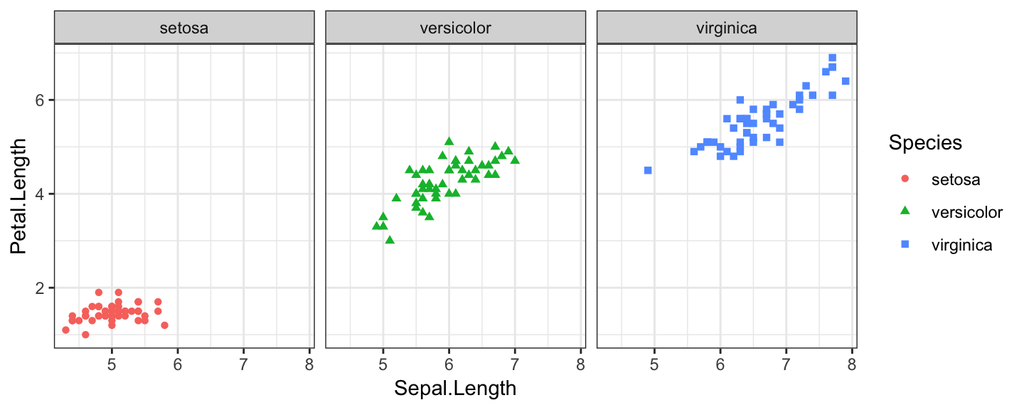

```r
gg +
  theme_bw()
```

## Gráfico: estilo

¿Cómo ajustar visualmente el gráfico?

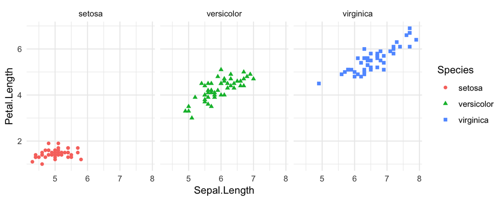

```r
gg +
  theme_minimal()
```

## Gráfico: estilo

Hay paquetes que proveen diseños adicionales.

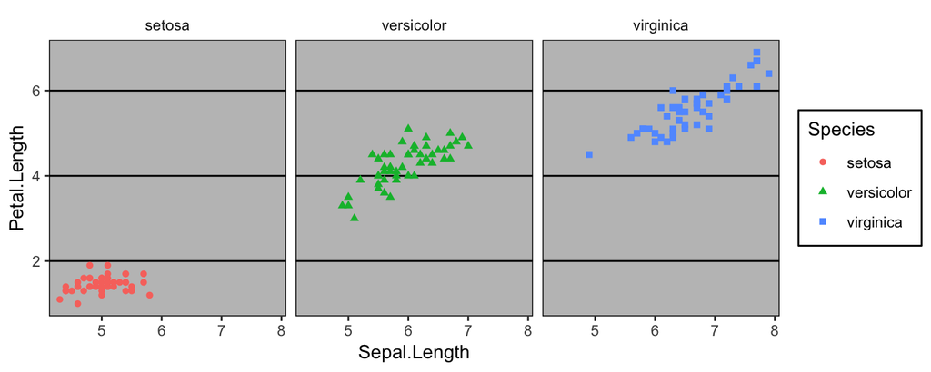

```r
pacman::p_load('ggthemes')

gg +
  ggthemes::theme_excel()
```

## Gráfico: guardar gráficos

Para guardar gráficos se puede utilizar la función `ggsave()`

```r
ggsave('gg_iris.jpg', gg)
ggsave('gg_iris.png', gg)
ggsave('gg_iris.pdf', gg)

ggsave('gg_iris_5cm.png', gg, width = 5, height = 5, units = 'cm')
ggsave('gg_iris_5cm_4.png', gg, width = 5, height = 5, units = 'cm', scale = 4)
```

## Análisis: Matrícula

```r
df_rbd_mat_18 <- df_mat_18 %>%
  group_by(RBD, NOM_RBD, NOM_COM_RBD, GEN_ALU, COD_ENSE2) %>%
  summarise(alumnos_n = n(),
            edad_mean = mean(EDAD_ALU))
```

## Gráfico: Matrícula

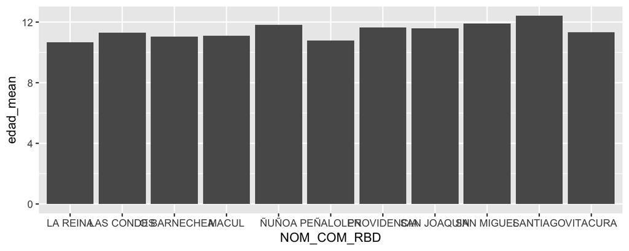

```r
df_com_edad <- df_rbd_mat_18 %>%
  group_by(NOM_COM_RBD) %>%
  summarise(edad_mean = sum(edad_mean * alumnos_n, na.rm = TRUE) / sum(alumnos_n, na.rm = TRUE))

ggplot(df_com_edad, aes(x = NOM_COM_RBD, y = edad_mean)) +
  geom_col()
```

## Gráfico: Matrícula

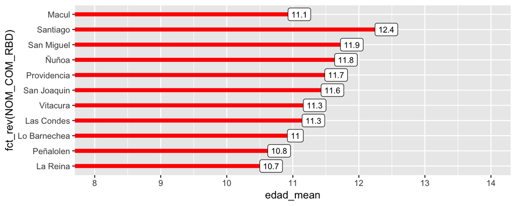

```r
x <- df_com_edad %>%
  arrange(desc(edad_mean)) %>%
  mutate(NOM_COM_RBD = str_to_title(NOM_COM_RBD),
         NOM_COM_RBD = forcats::as_factor(NOM_COM_RBD),
         NOM_COM_RBD = forcats::fct_relevel(NOM_COM_RBD, 'Macul'))

x %>%
  ggplot(aes(x = fct_rev(NOM_COM_RBD), y = edad_mean)) +
  geom_linerange(ymin = 0, aes(ymax = ..y..), colour = 'red', size = 2) +
  geom_label(size = 3, aes(label = round(..y.., 1))) +
  coord_flip() +
  scale_y_continuous(breaks = 0:14, limits = c(8,14))
```